# DV04

2023-10-03

## Question1

```r
library(tidyverse)

tv_ratings <- read_csv("https://raw.githubusercontent.com/vaiseys/dav-course/main/Data/tv_ratings.csv")

glimpse(tv_ratings)
```

```
## Rows: 2,266
## Columns: 7
## $ titleId      <chr> "tt2879552", "tt3148266", "tt3148266", "tt3148266", "tt31…
## $ seasonNumber <dbl> 1, 1, 2, 3, 4, 1, 2, 1, 2, 3, 4, 5, 6, 7, 8, 1, 1, 1, 1, …
## $ title        <chr> "11.22.63", "12 Monkeys", "12 Monkeys", "12 Monkeys", "12…
## $ date         <date> 2016-03-10, 2015-02-27, 2016-05-30, 2017-05-19, 2018-06-…
## $ av_rating    <dbl> 8.4890, 8.3407, 8.8196, 9.0369, 9.1363, 8.4370, 7.5089, 8…
## $ share        <dbl> 0.51, 0.46, 0.25, 0.19, 0.38, 2.38, 2.19, 6.67, 7.13, 5.8…
## $ genres       <chr> "Drama,Mystery,Sci-Fi", "Adventure,Drama,Mystery", "Adven…
```

```r
tv_long <- tv_ratings %>%
  group_by(title) %>%
  summarise(num_seasons = n()) %>%
  ungroup() %>%
  left_join(tv_ratings, by = "title")

tv_long <- tv_long %>%
  filter(num_seasons >= 5)

tv_long
```

```
## # A tibble: 1,085 × 8
##    title num_seasons titleId   seasonNumber date       av_rating share genres
##    <chr>       <int> <chr>            <dbl> <date>         <dbl> <dbl> <chr>
##  1 24              8 tt0285331            1 2002-02-16      8.56  6.67 Action,C…
##  2 24              8 tt0285331            2 2003-02-09      8.70  7.13 Action,C…
##  3 24              8 tt0285331            3 2004-02-09      8.72  5.88 Action,C…
##  4 24              8 tt0285331            4 2005-03-08      8.56  3.48 Action,C…
##  5 24              8 tt0285331            5 2006-03-10      8.78  2.15 Action,C…
##  6 24              8 tt0285331            6 2007-03-08      8.35  2.23 Action,C…
##  7 24              8 tt0285331            7 2009-03-10      8.49  2.04 Action,C…
##  8 24              8 tt0285331            8 2010-03-17      8.47  1.55 Action,C…
##  9 90210           5 tt1225901            1 2009-01-03      7.17  0.4  Comedy,D…
## 10 90210           5 tt1225901            2 2009-11-10      7.47  0.14 Comedy,D…
## # ℹ 1,075 more rows
```

```r
library(ggplot2)
```

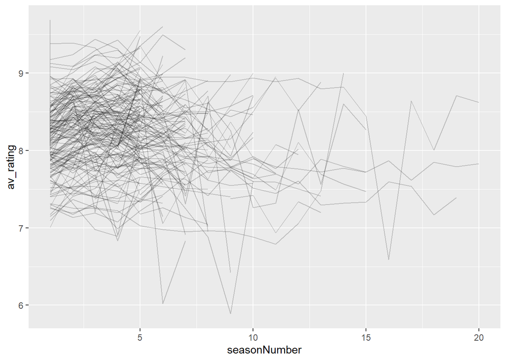

```r
ggplot(data = tv_long,
       mapping = aes(x = seasonNumber,
                     y = av_rating,
                     group = title,
                     fill = title))+
  geom_line(alpha = .2)
```

## Question2

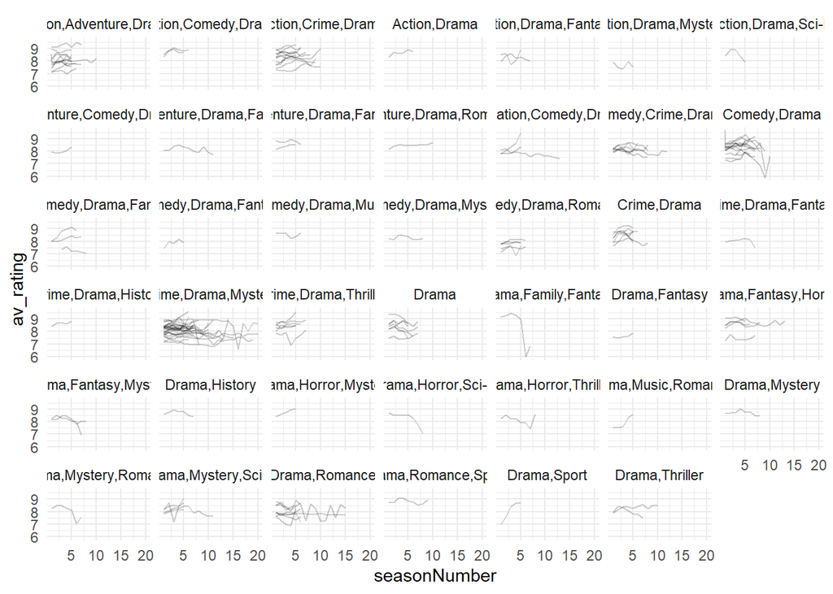

```r
ggplot(data = tv_long,
       mapping = aes(x = seasonNumber,
                     y = av_rating,
                     group = title,
                     fill = title))+
  geom_line(alpha = .2)+
  facet_wrap(~genres) +
  theme_minimal()
```

Lasts longer: Comedy, Crime, Drama; Crime, Drama, Mystery; Drama, Romance. Ratings do change a lot across seasons.

```r
genre_plummeted <- tv_long %>%
  filter (genres == "Drama,Family,Fantasy")
genre_plummeted
```

```
## # A tibble: 7 × 8
##   title       num_seasons titleId seasonNumber date       av_rating share genres
##   <chr>             <int> <chr>          <dbl> <date>         <dbl> <dbl> <chr>
## 1 Are You Af…           7 tt0103…            1 1993-04-17      9.17  8.27 Drama…
## 2 Are You Af…           7 tt0103…            2 1993-08-10      9.24  6.98 Drama…
## 3 Are You Af…           7 tt0103…            3 1994-02-23      9.43  2.6  Drama…
## 4 Are You Af…           7 tt0103…            4 1994-11-18      9.31  2.15 Drama…
## 5 Are You Af…           7 tt0103…            5 1995-12-15      8.95  2.31 Drama…
## 6 Are You Af…           7 tt0103…            6 1999-03-22      6.02  0.93 Drama…
## 7 Are You Af…           7 tt0103…            7 2000-04-24      6.83  0.68 Drama…
```

The tv show that plummeted is Are You Afraid of Dark.

## Question3

Let’s look at the `genres` that show up in the best rated shows.

First, filter the original data set - `tv_ratings` - so that it only includes rows where the average rating is higher or equal than 9.

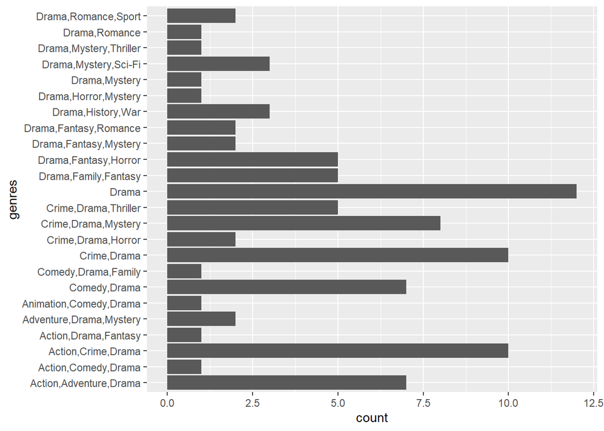

```r
Best_rated_shows <- tv_ratings %>%
  filter (av_rating >= 9)
ggplot(data = Best_rated_shows,
       mapping = aes(x = genres))+
  geom_bar()+
  coord_flip()
```

This function flipped the x and y axis so that we can read the names of the long genres!

Drama is the genre with the top-rated shows.

## Question 4

```r
comedies_dramas <- tv_ratings %>%
  mutate(is_comedy = if_else(str_detect(genres, "Comedy"),
                             1,
                             0)) %>% # If it contains the word comedy then 1, else 0
  filter(is_comedy == 1 | genres == "Drama") %>% # Keep comedies and dramas
  mutate(genres = if_else(genres == "Drama", # Make it so that we only have those two genres
                          "Drama",
                          "Comedy"))

glimpse(comedies_dramas)
```

```
## Rows: 684
## Columns: 8
## $ titleId      <chr> "tt0312081", "tt0312081", "tt0312081", "tt1225901", "tt12…
## $ seasonNumber <dbl> 1, 2, 3, 1, 2, 3, 4, 5, 1, 2, 1, 25, 1, 1, 2, 3, 4, 5, 1,…
## $ title        <chr> "8 Simple Rules", "8 Simple Rules", "8 Simple Rules", "90…
## $ date         <date> 2002-09-17, 2003-11-04, 2004-11-12, 2009-01-03, 2009-11-…
## $ av_rating    <dbl> 7.5000, 8.6000, 8.4043, 7.1735, 7.4686, 7.6858, 6.8344, 7…
## $ share        <dbl> 0.03, 0.10, 0.06, 0.40, 0.14, 0.10, 0.04, 0.01, 0.48, 0.4…
## $ genres       <chr> "Comedy", "Comedy", "Comedy", "Comedy", "Comedy", "Comedy…
## $ is_comedy    <dbl> 1, 1, 1, 1, 1, 1, 1, 1, 1, 1, 0, 1, 1, 1, 1, 1, 1, 1, 1, …
```

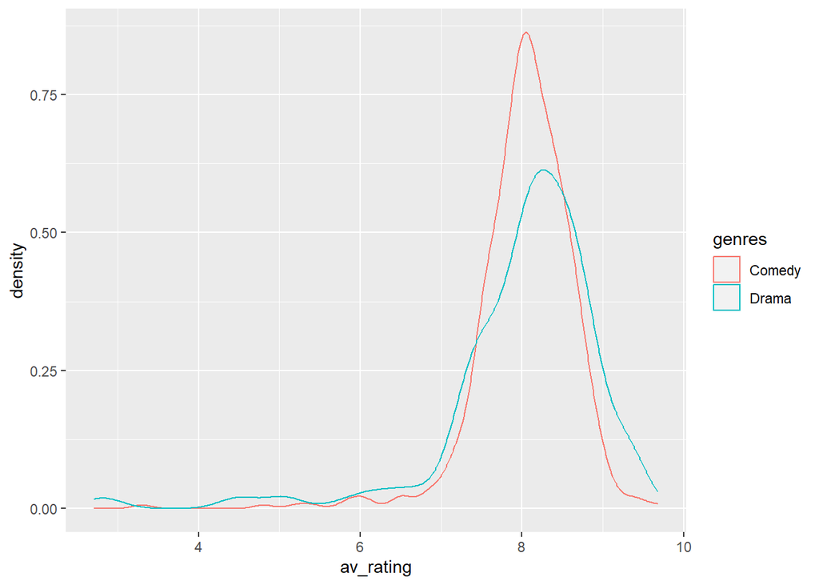

```r
ggplot(comedies_dramas, aes(x = av_rating, color = genres)) +
  geom_density(alpha = 0.5)
```

## Question5

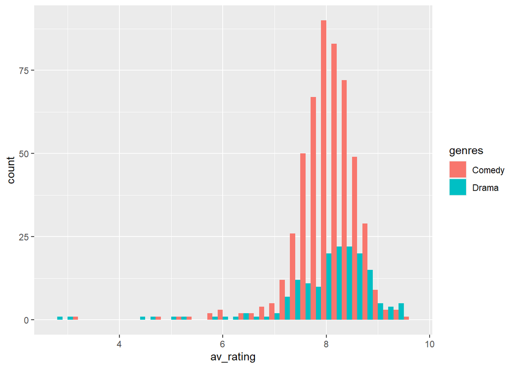

```r
ggplot(comedies_dramas, aes(x = av_rating, fill = genres)) +
  geom_histogram(binwidth = 0.2, position = "dodge")
```

By histogram I can tell the distribution of the average ratings for each genre.

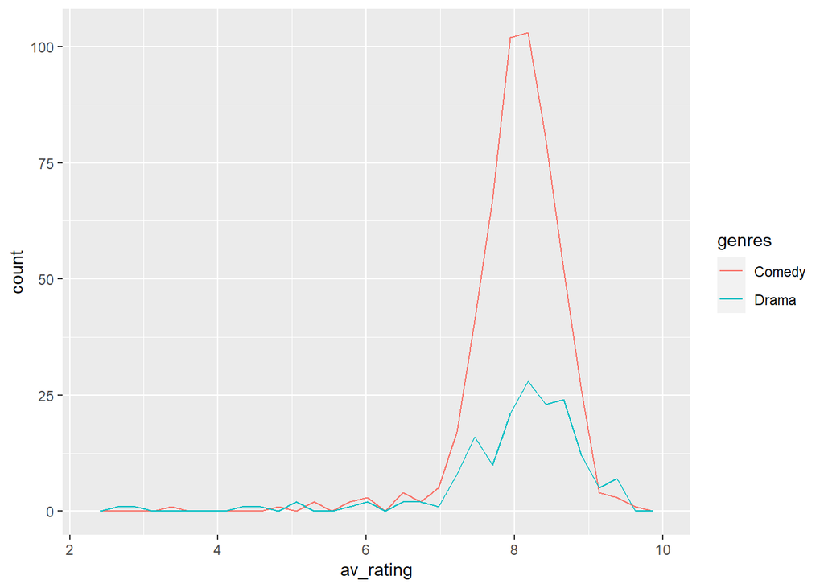

```r
ggplot(comedies_dramas, aes(x = av_rating, color = genres)) +
  geom_freqpoly()
```

By freqpoly function helps to identify trends of the ratings.

All of the three plots could do useful comparisons, while I would prefer freqpoly plot, since it more explicitly shows the trends and differences between to genres. The histogram could do the same thing but personally I think the freqpoly plot is easier to read and have an overall comparison.

## Question6

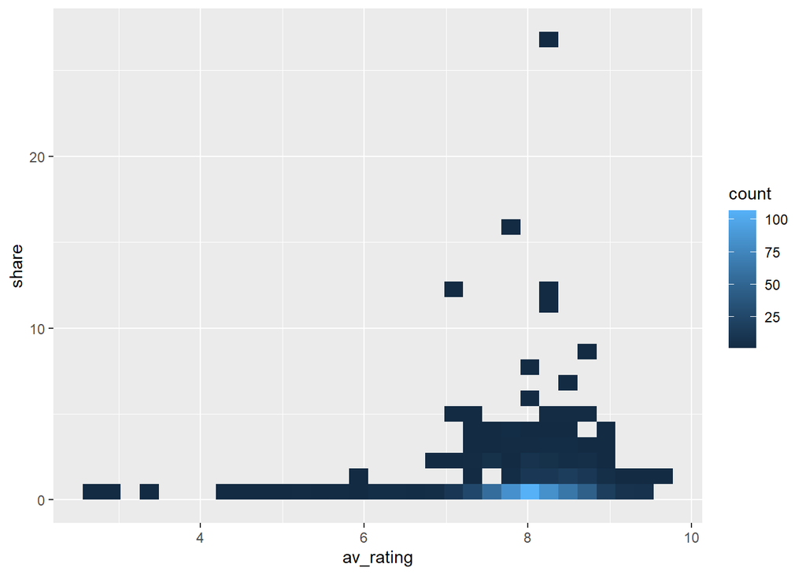

```r
ggplot(data = comedies_dramas,
       mapping = aes(x = av_rating,
                     y = share)) +
  geom_bin_2d()
```

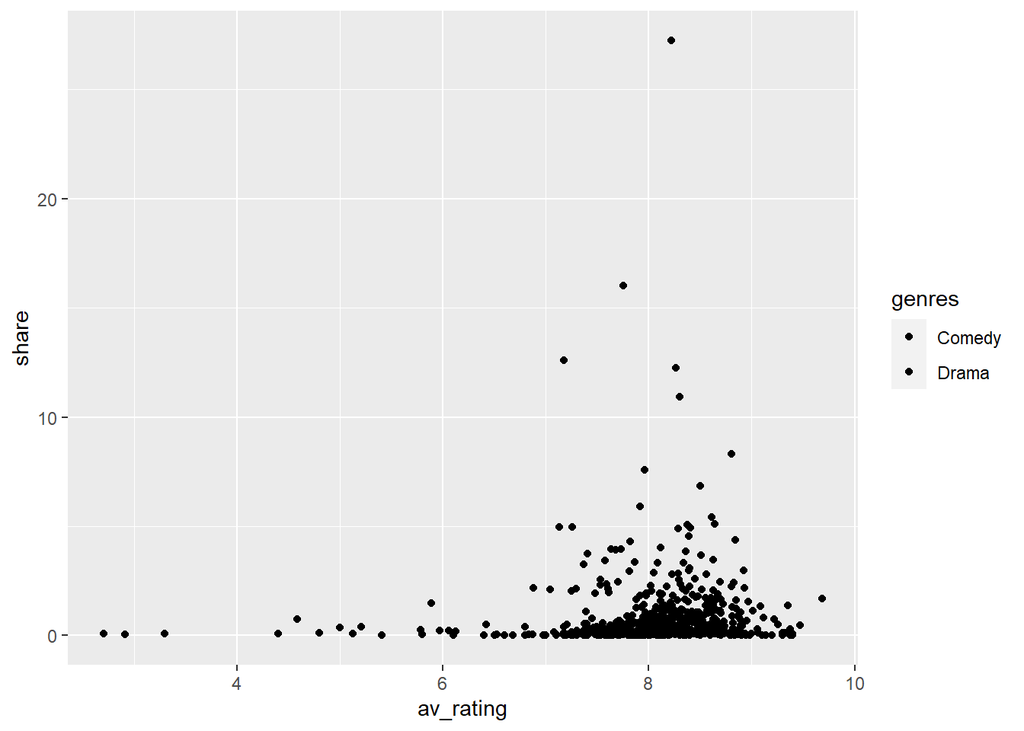

```r
ggplot(data = comedies_dramas,
       mapping = aes(x = av_rating,
                     y = share,
                     fill = genres)) +
  geom_point()
```

The 2D bin plot helps to identify regions of the plot where there is a higher concentration of data points, indicating areas where average rating and share tend to cluster together(when av_rating = 8 and share<=5), comparing to scatter plot. I can see that higher share doesn’t necessarily indicate higher av_rating.

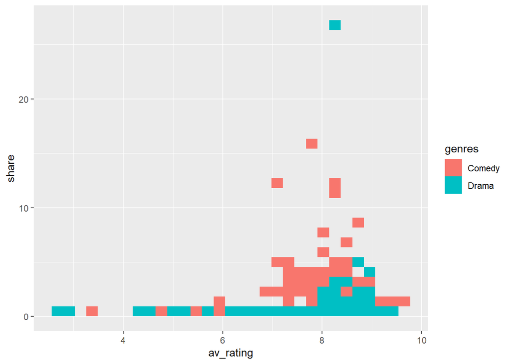

```r
ggplot(data = comedies_dramas,
       mapping = aes(x = av_rating,
                     y = share,
                     fill = genres)) +
  geom_bin_2d()
```